# Star Hotels Project

## Context

A significant number of hotel bookings are called-off due to cancellations or no-shows. The typical reasons for cancellations include change of plans, scheduling conflicts, etc. This is often made easier by the option to do so free of charge or preferably at a low cost which is beneficial to hotel guests but it is a less desirable and possibly revenue-diminishing factor for hotels to deal with. Such losses are particularly high on last-minute cancellations.

The new technologies involving online booking channels have dramatically changed customers’ booking possibilities and behavior. This adds a further dimension to the challenge of how hotels handle cancellations, which are no longer limited to traditional booking and guest characteristics.

The cancellation of bookings impact a hotel on various fronts:

- Loss of resources (revenue) when the hotel cannot resell the room.
- Additional costs of distribution channels by increasing commissions or paying for publicity to help sell these rooms.
- Lowering prices last minute, so the hotel can resell a room, resulting in reducing the profit margin.
- Human resources to make arrangements for the guests.

## Objective

The increasing number of cancellations calls for a Machine Learning based solution that can help in predicting which booking is likely to be canceled. Star Hotels Group has a chain of hotels in Portugal, they are facing problems with the high number of booking cancellations and have reached out to your firm for data-driven solutions. You as a data scientist have to analyze the data provided to find which factors have a high influence on booking cancellations, build a predictive model that can predict which booking is going to be canceled in advance, and help in formulating profitable policies for cancellations and refunds.

## Data Description

The data contains the different attributes of customers' booking details. The detailed data dictionary is given below.

### Data Dictionary

- no_of_adults: Number of adults
- no_of_children: Number of Children
- no_of_weekend_nights: Number of weekend nights (Saturday or Sunday) the guest stayed or booked to stay at the hotel
- no_of_week_nights: Number of week nights (Monday to Friday) the guest stayed or booked to stay at the hotel
- type_of_meal_plan: Type of meal plan booked by the customer:
- Not Selected – No meal plan selected
  - Meal Plan 1 – Breakfast
  - Meal Plan 2 – Half board (breakfast and one other meal)
  - Meal Plan 3 – Full board (breakfast, lunch, and dinner)
- required_car_parking_space: Does the customer require a car parking space? (0 - No, 1- Yes)
- room_type_reserved: Type of room reserved by the customer. The values are ciphered (encoded) by Star Hotels.
- lead_time: Number of days between the date of booking and the arrival date
- arrival_year: Year of arrival date
- arrival_month: Month of arrival date
- arrival_date: Date of the month
- market_segment_type: Market segment designation.
- repeated_guest: Is the customer a repeated guest? (0 - No, 1- Yes)
- no_of_previous_cancellations: Number of previous bookings that were canceled by the customer prior to the current booking
- no_of_previous_bookings_not_canceled: Number of previous bookings not canceled by the customer prior to the current booking
- avg_price_per_room: Average price per day of the reservation; prices of the rooms are dynamic. (in euros)
- no_of_special_requests: Total number of special requests made by the customer (e.g. high floor, view from the room, etc)
- booking_status: Flag indicating if the booking was canceled or not.

# Import initial Libraries

```python
# this will help in making the Python code more structured automatically (good coding practice)

import warnings

warnings.filterwarnings("ignore")
from statsmodels.tools.sm_exceptions import ConvergenceWarning

warnings.simplefilter("ignore", ConvergenceWarning)

# Libraries to help with reading and manipulating data

import pandas as pd
import numpy as np

# Library to split data
from sklearn.model_selection import train_test_split

# libaries to help with data visualization
import matplotlib.pyplot as plt
import seaborn as sns

# Removes the limit for the number of displayed columns
pd.set_option("display.max_columns", None)
# Sets the limit for the number of displayed rows
pd.set_option("display.max_rows", 200)


# To build model for prediction
import statsmodels.stats.api as sms
from statsmodels.stats.outliers_influence import variance_inflation_factor
import statsmodels.api as sm
from statsmodels.tools.tools import add_constant
from sklearn.linear_model import LogisticRegression


# To get diferent metric scores
from sklearn.metrics import (
    f1_score,
    accuracy_score,
    recall_score,
    precision_score,
    confusion_matrix,
    roc_auc_score,
    plot_confusion_matrix,
    precision_recall_curve,
    roc_curve,
)
```

# Load and Review the Data

```python
logdata = pd.read_csv("StarHotelsGroup.csv") #import the data
```

```python
logdata.head() # To check first 5 rows of data set
```

|  | no_of_adults | no_of_children | no_of_weekend_nights | no_of_week_nights | type_of_meal_plan | required_car_parking_space | room_type_reserved | lead_time | arrival_year | arrival_month | arrival_date | market_segment_type | repeated_guest | no_of_previous_cancellations | no_of_previous_bookings_not_canceled | avg_price_per_room | no_of_special_requests | booking_status |
| --- | --- | --- | --- | --- | --- | --- | --- | --- | --- | --- | --- | --- | --- | --- | --- | --- | --- | --- |
| 0 | 2 | 0 | 1 | 2 | Meal Plan 1 | 0 | Room_Type 1 | 224 | 2017 | 10 | 2 | Offline | 0 | 0 | 0 | 65.00 | 0 | Not_Canceled |
| 1 | 2 | 0 | 2 | 3 | Not Selected | 0 | Room_Type 1 | 5 | 2018 | 11 | 6 | Online | 0 | 0 | 0 | 106.68 | 1 | Not_Canceled |
| 2 | 1 | 0 | 2 | 1 | Meal Plan 1 | 0 | Room_Type 1 | 1 | 2018 | 2 | 28 | Online | 0 | 0 | 0 | 60.00 | 0 | Canceled |
| 3 | 2 | 0 | 0 | 2 | Meal Plan 1 | 0 | Room_Type 1 | 211 | 2018 | 5 | 20 | Online | 0 | 0 | 0 | 100.00 | 0 | Canceled |
| 4 | 3 | 0 | 0 | 3 | Not Selected | 0 | Room_Type 1 | 277 | 2019 | 7 | 13 | Online | 0 | 0 | 0 | 89.10 | 2 | Canceled |

```python
logdata.info() # Identify the data types.
```

```
<class 'pandas.core.frame.DataFrame'>
RangeIndex: 56926 entries, 0 to 56925
Data columns (total 18 columns):
 #   Column                                Non-Null Count  Dtype
---  ------                                --------------  -----
 0   no_of_adults                          56926 non-null  int64
 1   no_of_children                        56926 non-null  int64
 2   no_of_weekend_nights                  56926 non-null  int64
 3   no_of_week_nights                     56926 non-null  int64
 4   type_of_meal_plan                     56926 non-null  object
 5   required_car_parking_space            56926 non-null  int64
 6   room_type_reserved                    56926 non-null  object
 7   lead_time                             56926 non-null  int64
 8   arrival_year                          56926 non-null  int64
 9   arrival_month                         56926 non-null  int64
 10  arrival_date                          56926 non-null  int64
 11  market_segment_type                   56926 non-null  object
 12  repeated_guest                        56926 non-null  int64
 13  no_of_previous_cancellations          56926 non-null  int64
 14  no_of_previous_bookings_not_canceled  56926 non-null  int64
 15  avg_price_per_room                    56926 non-null  float64
 16  no_of_special_requests                56926 non-null  int64
 17  booking_status                        56926 non-null  object
dtypes: float64(1), int64(13), object(4)
memory usage: 7.8+ MB
```

```python
logdata.shape # Check number of columns and rows in data frame
```

```
(56926, 18)
```

```python
logdata.isnull().values.any() # If there are any null values in data set
```

```
False
```

The data does not include any null values.

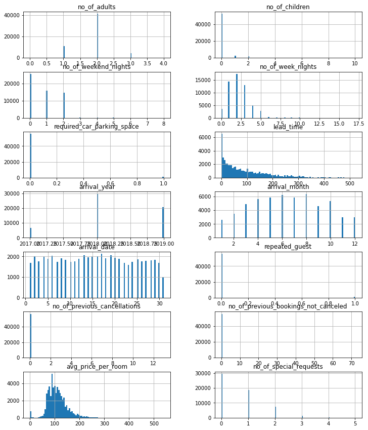

```python
columns = list(logdata)[0:-1] # Excluding Outcome column which has only
logdata[columns].hist(stacked=False, bins=100, figsize=(12,30), layout=(14,2));
# Histogram of first 8 columns
```

## Identify duplicates

```python
logdata.groupby(logdata.columns.tolist(),as_index=False).size()
```

|  | no_of_adults | no_of_children | no_of_weekend_nights | no_of_week_nights | type_of_meal_plan | required_car_parking_space | room_type_reserved | lead_time | arrival_year | arrival_month | arrival_date | market_segment_type | repeated_guest | no_of_previous_cancellations | no_of_previous_bookings_not_canceled | avg_price_per_room | no_of_special_requests | booking_status | size |
| --- | --- | --- | --- | --- | --- | --- | --- | --- | --- | --- | --- | --- | --- | --- | --- | --- | --- | --- | --- |
| 0 | 0 | 1 | 2 | 4 | Meal Plan 1 | 0 | Room_Type 2 | 109 | 2018 | 4 | 1 | Online | 0 | 0 | 0 | 73.74 | 1 | Not_Canceled | 1 |
| 1 | 0 | 1 | 2 | 5 | Meal Plan 1 | 0 | Room_Type 2 | 239 | 2019 | 6 | 4 | Online | 0 | 0 | 0 | 107.45 | 1 | Canceled | 1 |
| 2 | 0 | 2 | 0 | 1 | Meal Plan 1 | 0 | Room_Type 1 | 130 | 2018 | 3 | 25 | Complementary | 0 | 0 | 0 | 6.00 | 2 | Not_Canceled | 1 |
| 3 | 0 | 2 | 0 | 1 | Meal Plan 1 | 0 | Room_Type 2 | 0 | 2018 | 1 | 7 | Online | 0 | 0 | 0 | 6.00 | 0 | Not_Canceled | 1 |
| 4 | 0 | 2 | 0 | 1 | Meal Plan 1 | 0 | Room_Type 2 | 3 | 2018 | 6 | 16 | Online | 0 | 0 | 0 | 131.78 | 0 | Not_Canceled | 1 |
| ... | ... | ... | ... | ... | ... | ... | ... | ... | ... | ... | ... | ... | ... | ... | ... | ... | ... | ... | ... |
| 42571 | 4 | 0 | 2 | 1 | Meal Plan 1 | 0 | Room_Type 7 | 61 | 2018 | 7 | 10 | Online | 0 | 0 | 0 | 256.10 | 0 | Canceled | 1 |
| 42572 | 4 | 0 | 2 | 1 | Meal Plan 1 | 0 | Room_Type 7 | 74 | 2018 | 12 | 25 | Online | 0 | 0 | 0 | 174.42 | 2 | Not_Canceled | 1 |
| 42573 | 4 | 0 | 2 | 3 | Meal Plan 1 | 0 | Room_Type 7 | 31 | 2019 | 2 | 16 | Online | 0 | 0 | 0 | 191.39 | 1 | Not_Canceled | 1 |
| 42574 | 4 | 0 | 2 | 3 | Meal Plan 1 | 0 | Room_Type 7 | 75 | 2019 | 3 | 3 | Online | 0 | 0 | 0 | 202.51 | 0 | Canceled | 1 |
| 42575 | 4 | 0 | 2 | 3 | Meal Plan 1 | 0 | Room_Type 7 | 75 | 2019 | 3 | 4 | Online | 0 | 0 | 0 | 202.51 | 1 | Canceled | 1 |

42576 rows × 19 columns

```python
length1 = len(logdata)

print(length1)
```

```
56926
```

The data includes 14,350 duplicate rows.

These duplicates should be removed.

# Removing Duplicates

```python
logdata.drop_duplicates()
```

|  | no_of_adults | no_of_children | no_of_weekend_nights | no_of_week_nights | type_of_meal_plan | required_car_parking_space | room_type_reserved | lead_time | arrival_year | arrival_month | arrival_date | market_segment_type | repeated_guest | no_of_previous_cancellations | no_of_previous_bookings_not_canceled | avg_price_per_room | no_of_special_requests | booking_status |
| --- | --- | --- | --- | --- | --- | --- | --- | --- | --- | --- | --- | --- | --- | --- | --- | --- | --- | --- |
| 0 | 2 | 0 | 1 | 2 | Meal Plan 1 | 0 | Room_Type 1 | 224 | 2017 | 10 | 2 | Offline | 0 | 0 | 0 | 65.00 | 0 | Not_Canceled |
| 1 | 2 | 0 | 2 | 3 | Not Selected | 0 | Room_Type 1 | 5 | 2018 | 11 | 6 | Online | 0 | 0 | 0 | 106.68 | 1 | Not_Canceled |
| 2 | 1 | 0 | 2 | 1 | Meal Plan 1 | 0 | Room_Type 1 | 1 | 2018 | 2 | 28 | Online | 0 | 0 | 0 | 60.00 | 0 | Canceled |
| 3 | 2 | 0 | 0 | 2 | Meal Plan 1 | 0 | Room_Type 1 | 211 | 2018 | 5 | 20 | Online | 0 | 0 | 0 | 100.00 | 0 | Canceled |
| 4 | 3 | 0 | 0 | 3 | Not Selected | 0 | Room_Type 1 | 277 | 2019 | 7 | 13 | Online | 0 | 0 | 0 | 89.10 | 2 | Canceled |
| ... | ... | ... | ... | ... | ... | ... | ... | ... | ... | ... | ... | ... | ... | ... | ... | ... | ... | ... |
| 56920 | 2 | 0 | 2 | 6 | Meal Plan 1 | 0 | Room_Type 1 | 148 | 2018 | 7 | 1 | Online | 0 | 0 | 0 | 98.39 | 2 | Not_Canceled |
| 56921 | 2 | 1 | 0 | 1 | Meal Plan 2 | 0 | Room_Type 4 | 45 | 2019 | 6 | 15 | Online | 0 | 0 | 0 | 163.88 | 1 | Not_Canceled |
| 56922 | 2 | 0 | 1 | 1 | Meal Plan 1 | 0 | Room_Type 1 | 320 | 2019 | 5 | 15 | Offline | 0 | 0 | 0 | 90.00 | 1 | Canceled |
| 56923 | 2 | 0 | 0 | 3 | Not Selected | 0 | Room_Type 1 | 63 | 2018 | 4 | 21 | Online | 0 | 0 | 0 | 94.50 | 0 | Canceled |
| 56924 | 2 | 0 | 2 | 2 | Not Selected | 0 | Room_Type 1 | 6 | 2019 | 4 | 28 | Online | 0 | 0 | 0 | 162.50 | 2 | Not_Canceled |

42576 rows × 18 columns

```python
logdata1 = logdata.drop_duplicates()
```

```python
logdata1.info()
```

```
<class 'pandas.core.frame.DataFrame'>
Int64Index: 42576 entries, 0 to 56924
Data columns (total 18 columns):
 #   Column                                Non-Null Count  Dtype
---  ------                                --------------  -----
 0   no_of_adults                          42576 non-null  int64
 1   no_of_children                        42576 non-null  int64
 2   no_of_weekend_nights                  42576 non-null  int64
 3   no_of_week_nights                     42576 non-null  int64
 4   type_of_meal_plan                     42576 non-null  object
 5   required_car_parking_space            42576 non-null  int64
 6   room_type_reserved                    42576 non-null  object
 7   lead_time                             42576 non-null  int64
 8   arrival_year                          42576 non-null  int64
 9   arrival_month                         42576 non-null  int64
 10  arrival_date                          42576 non-null  int64
 11  market_segment_type                   42576 non-null  object
 12  repeated_guest                        42576 non-null  int64
 13  no_of_previous_cancellations          42576 non-null  int64
 14  no_of_previous_bookings_not_canceled  42576 non-null  int64
 15  avg_price_per_room                    42576 non-null  float64
 16  no_of_special_requests                42576 non-null  int64
 17  booking_status                        42576 non-null  object
dtypes: float64(1), int64(13), object(4)
memory usage: 6.2+ MB
```

# Observations:

- The Source Data includes 56,926 rows and 18 columns.
- The Source Data included 14,350 duplicates. These duplicates were removed to reduce the rows to 42,576.
- The Data types are 1 float, 13 integers, and 4 objects.
  - Float: Average Price per Room
  - Integer: no_of_adults, no_of_children, no_of_weekend_nights, no_of_week_nights, required_car_parking_space, lead_time, arrival_year, arrival_month, arrival_date, repeated_gues, no_of_previous_cancellations, no_of_previous_bookings_not_canceled, and no_of_special_requests.
  - Object: type_of_meal_plan, room_type_reserved, market_segment_type, and booking_status
- The Data does not include any missing values.
- The Dependent Variable is Booking Status.

```python
logdata1.describe().T # Learn the characteristics of the data.
```

|  | count | mean | std | min | 25% | 50% | 75% | max |
| --- | --- | --- | --- | --- | --- | --- | --- | --- |
| no_of_adults | 42576.0 | 1.916737 | 0.527524 | 0.0 | 2.0 | 2.0 | 2.0 | 4.0 |
| no_of_children | 42576.0 | 0.142146 | 0.459920 | 0.0 | 0.0 | 0.0 | 0.0 | 10.0 |
| no_of_weekend_nights | 42576.0 | 0.895270 | 0.887864 | 0.0 | 0.0 | 1.0 | 2.0 | 8.0 |
| no_of_week_nights | 42576.0 | 2.321167 | 1.519328 | 0.0 | 1.0 | 2.0 | 3.0 | 17.0 |
| required_car_parking_space | 42576.0 | 0.034362 | 0.182160 | 0.0 | 0.0 | 0.0 | 0.0 | 1.0 |
| lead_time | 42576.0 | 77.315953 | 77.279616 | 0.0 | 16.0 | 53.0 | 118.0 | 521.0 |
| arrival_year | 42576.0 | 2018.297891 | 0.626126 | 2017.0 | 2018.0 | 2018.0 | 2019.0 | 2019.0 |
| arrival_month | 42576.0 | 6.365488 | 3.051924 | 1.0 | 4.0 | 6.0 | 9.0 | 12.0 |
| arrival_date | 42576.0 | 15.682873 | 8.813991 | 1.0 | 8.0 | 16.0 | 23.0 | 31.0 |
| repeated_guest | 42576.0 | 0.030886 | 0.173011 | 0.0 | 0.0 | 0.0 | 0.0 | 1.0 |
| no_of_previous_cancellations | 42576.0 | 0.025413 | 0.358194 | 0.0 | 0.0 | 0.0 | 0.0 | 13.0 |
| no_of_previous_bookings_not_canceled | 42576.0 | 0.222731 | 2.242308 | 0.0 | 0.0 | 0.0 | 0.0 | 72.0 |
| avg_price_per_room | 42576.0 | 112.375800 | 40.865896 | 0.0 | 85.5 | 107.0 | 135.0 | 540.0 |
| no_of_special_requests | 42576.0 | 0.768109 | 0.837264 | 0.0 | 0.0 | 1.0 | 1.0 | 5.0 |

Looking at object/categorical data

```python
# filtering object type columns
cat_columns = logdata.describe(include=["object"]).columns
cat_columns
```

```
Index(['type_of_meal_plan', 'room_type_reserved', 'market_segment_type',
       'booking_status'],
      dtype='object')
```

```python
for i in cat_columns:
    print("Unique values in", i, "are :")
    print(logdata[i].value_counts())
    print("*" * 50)
```

```
Unique values in type_of_meal_plan are :
Meal Plan 1     42330
Not Selected    10072
Meal Plan 2      4516
Meal Plan 3         8
Name: type_of_meal_plan, dtype: int64
Unique values in room_type_reserved are :
Room_Type 1    42807
Room_Type 4    10413
Room_Type 6     1581
Room_Type 5      983
Room_Type 2      823
Room_Type 7      312
Room_Type 3        7
Name: room_type_reserved, dtype: int64
Unique values in market_segment_type are :
Online           39490
Offline          13875
Corporate         2796
Complementary      536
Aviation           229
Name: market_segment_type, dtype: int64
Unique values in booking_status are :
Not_Canceled    35378
Canceled        21548
Name: booking_status, dtype: int64
```

- Meal Plan 1 is the most common meal plan.
- Room Type 1 is the most requested room.
- Online booking is the most common market segment.
- Cancellations occur 21,548/56,926 or 37.85% of the time.
- Complementary bookings need to be further investigated as this market segment might add noise to the analysis.

## Complementary Market Segment

```python
logdata1[logdata1["market_segment_type"] == "Complementary"]
```

|  | no_of_adults | no_of_children | no_of_weekend_nights | no_of_week_nights | type_of_meal_plan | required_car_parking_space | room_type_reserved | lead_time | arrival_year | arrival_month | arrival_date | market_segment_type | repeated_guest | no_of_previous_cancellations | no_of_previous_bookings_not_canceled | avg_price_per_room | no_of_special_requests | booking_status |
| --- | --- | --- | --- | --- | --- | --- | --- | --- | --- | --- | --- | --- | --- | --- | --- | --- | --- | --- |
| 98 | 1 | 0 | 0 | 1 | Meal Plan 1 | 0 | Room_Type 1 | 2 | 2017 | 9 | 10 | Complementary | 0 | 0 | 0 | 0.0 | 1 | Not_Canceled |
| 129 | 1 | 0 | 2 | 0 | Meal Plan 1 | 0 | Room_Type 1 | 17 | 2019 | 5 | 28 | Complementary | 1 | 0 | 3 | 0.0 | 1 | Not_Canceled |
| 226 | 1 | 0 | 0 | 2 | Meal Plan 1 | 0 | Room_Type 1 | 13 | 2018 | 6 | 1 | Complementary | 1 | 3 | 5 | 0.0 | 1 | Not_Canceled |
| 324 | 1 | 0 | 0 | 0 | Meal Plan 1 | 0 | Room_Type 1 | 4 | 2018 | 2 | 27 | Complementary | 0 | 0 | 0 | 0.0 | 1 | Not_Canceled |
| 407 | 1 | 0 | 0 | 2 | Meal Plan 1 | 0 | Room_Type 1 | 1 | 2017 | 8 | 12 | Complementary | 1 | 0 | 1 | 0.0 | 1 | Not_Canceled |
| ... | ... | ... | ... | ... | ... | ... | ... | ... | ... | ... | ... | ... | ... | ... | ... | ... | ... | ... |
| 55728 | 1 | 0 | 0 | 1 | Meal Plan 1 | 0 | Room_Type 1 | 0 | 2019 | 8 | 23 | Complementary | 1 | 5 | 21 | 0.0 | 3 | Not_Canceled |
| 56462 | 2 | 0 | 0 | 1 | Meal Plan 1 | 0 | Room_Type 6 | 4 | 2019 | 6 | 2 | Complementary | 1 | 4 | 13 | 0.0 | 3 | Not_Canceled |
| 56471 | 1 | 0 | 0 | 1 | Meal Plan 1 | 0 | Room_Type 7 | 0 | 2018 | 6 | 7 | Complementary | 1 | 4 | 17 | 0.0 | 1 | Not_Canceled |
| 56624 | 1 | 0 | 1 | 1 | Meal Plan 1 | 0 | Room_Type 7 | 0 | 2018 | 3 | 21 | Complementary | 1 | 3 | 15 | 0.0 | 1 | Not_Canceled |
| 56757 | 1 | 0 | 1 | 2 | Meal Plan 1 | 0 | Room_Type 1 | 2 | 2017 | 11 | 9 | Complementary | 0 | 0 | 0 | 79.0 | 0 | Not_Canceled |

496 rows × 18 columns

```python
logdata1[logdata1["market_segment_type"] == "Complementary"]["booking_status"].value_counts()
```

```
Not_Canceled    496
Name: booking_status, dtype: int64
```

## Observation

Complementary Market Segment should be removed since there are not any cancellations in this market segment.

```python
logdata1.drop(logdata1.loc[logdata1['market_segment_type']=='Complementary'].index, inplace=True)
```

```python
logdata1.info()
```

```
<class 'pandas.core.frame.DataFrame'>
Int64Index: 42080 entries, 0 to 56924
Data columns (total 18 columns):
 #   Column                                Non-Null Count  Dtype
---  ------                                --------------  -----
 0   no_of_adults                          42080 non-null  int64
 1   no_of_children                        42080 non-null  int64
 2   no_of_weekend_nights                  42080 non-null  int64
 3   no_of_week_nights                     42080 non-null  int64
 4   type_of_meal_plan                     42080 non-null  object
 5   required_car_parking_space            42080 non-null  int64
 6   room_type_reserved                    42080 non-null  object
 7   lead_time                             42080 non-null  int64
 8   arrival_year                          42080 non-null  int64
 9   arrival_month                         42080 non-null  int64
 10  arrival_date                          42080 non-null  int64
 11  market_segment_type                   42080 non-null  object
 12  repeated_guest                        42080 non-null  int64
 13  no_of_previous_cancellations          42080 non-null  int64
 14  no_of_previous_bookings_not_canceled  42080 non-null  int64
 15  avg_price_per_room                    42080 non-null  float64
 16  no_of_special_requests                42080 non-null  int64
 17  booking_status                        42080 non-null  object
dtypes: float64(1), int64(13), object(4)
memory usage: 6.1+ MB
```

The Complementary bookings were removed from the dataframe.

# Univariate Analysis

```python
def histogram_boxplot(data, feature, figsize=(12, 7), kde=False, bins=None):
    """
    Boxplot and histogram combined

    data: dataframe
    feature: dataframe column
    figsize: size of figure (default (12,7))
    kde: whether to show the density curve (default False)
    bins: number of bins for histogram (default None)
    """
    f2, (ax_box2, ax_hist2) = plt.subplots(
        nrows=2,  # Number of rows of the subplot grid= 2
        sharex=True,  # x-axis will be shared among all subplots
        gridspec_kw={"height_ratios": (0.25, 0.75)},
        figsize=figsize,
    )  # creating the 2 subplots
    sns.boxplot(
        data=data, x=feature, ax=ax_box2, showmeans=True, color="violet"
    )  # boxplot will be created and a star will indicate the mean value of the column
    sns.histplot(
        data=data, x=feature, kde=kde, ax=ax_hist2, bins=bins, palette="winter"
    ) if bins else sns.histplot(
        data=data, x=feature, kde=kde, ax=ax_hist2
    )  # For histogram
    ax_hist2.axvline(
        data[feature].mean(), color="green", linestyle="--"
    )  # Add mean to the histogram
    ax_hist2.axvline(
        data[feature].median(), color="black", linestyle="-"
    )  # Add median to the histogram
```

## Observations on Number of Adults

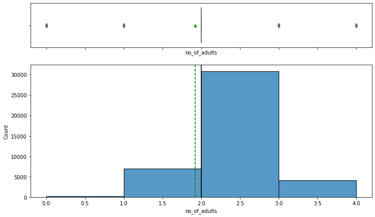

```python
histogram_boxplot(logdata1, "no_of_adults", bins=4)
```

Most bookings include two adults.

## Observations on Number of Children

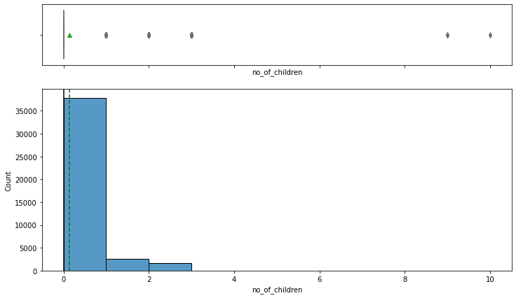

```python
histogram_boxplot(logdata1, "no_of_children", bins=10)
```

The data is right skewed with most visitors not bringing any children.

## Observations on Number of Weekend Nights

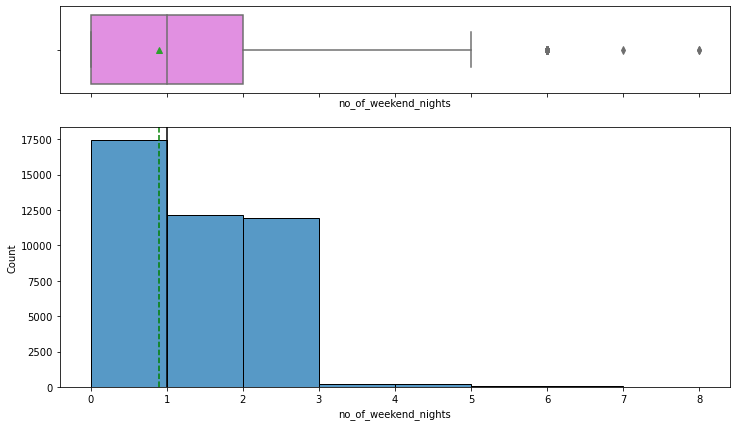

```python
histogram_boxplot(logdata1, "no_of_weekend_nights", bins=8)
```

The data is right skewed with most visitors Staying for 1-3 wekend nights.

## Observations on Number of Week Nights

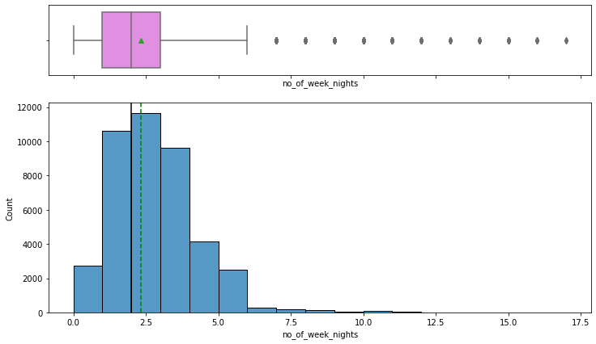

```python
histogram_boxplot(logdata1, "no_of_week_nights", bins=17)
```

The data is right skewed with most visitors between 1 and 5 days.

## Observations on Needing a Parking Space

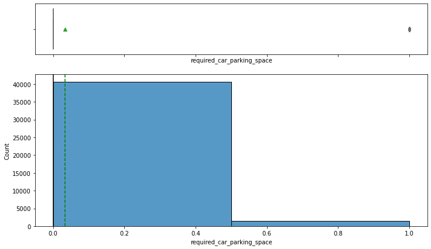

```python
histogram_boxplot(logdata1, "required_car_parking_space", bins=2)
```

The majority of guests do not need a parking space.

## Observations on Lead Time

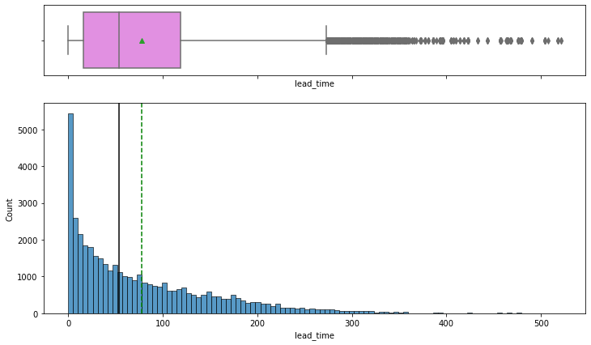

```python
histogram_boxplot(logdata1, "lead_time", bins=100)
```

## Observations on Repeat Guests

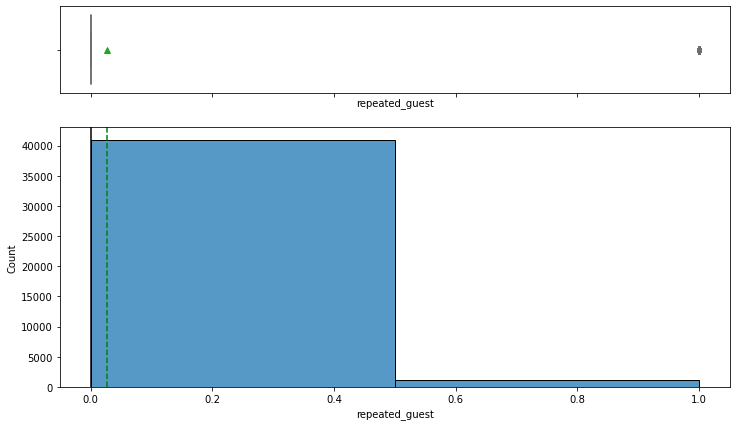

```python
histogram_boxplot(logdata1, "repeated_guest", bins=2)
```

The majority of guests are not repeat visitors.

## Observations on Guest Cancellations

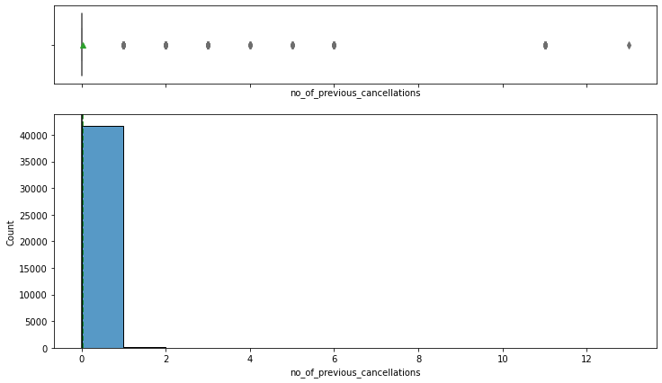

```python
histogram_boxplot(logdata1, "no_of_previous_cancellations", bins=13)
```

The majority of guests do not have previous cancellations.

## Observations on Bookings not Canceled

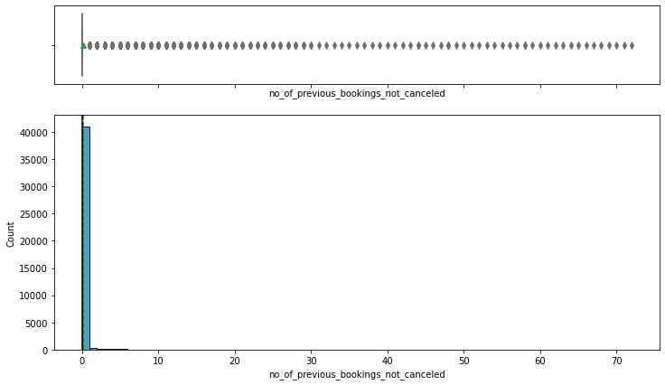

```python
histogram_boxplot(logdata1, "no_of_previous_bookings_not_canceled", bins=72)
```

Most guests only stay at the hotel once.

## Observations on Average Price per Room

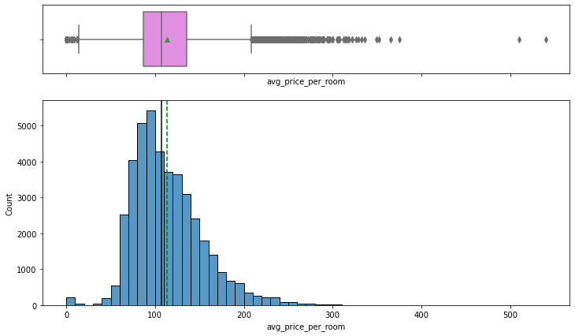

```python
histogram_boxplot(logdata1, "avg_price_per_room", bins=54)
```

## Observations on Special Requests

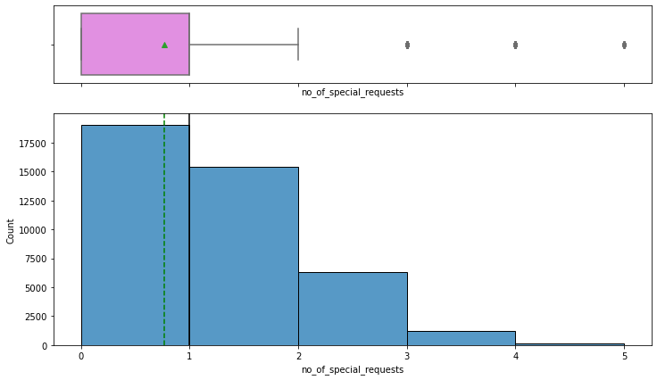

```python
histogram_boxplot(logdata1, "no_of_special_requests", bins=5)
```

The data is right skewed with most guests having one or fewer special requests.

```python
# function to create labeled barplots For percentage Univariate Analysis


def labeled_barplot(data, feature, perc=False, n=None):
    """
    Barplot with percentage at the top

    data: dataframe
    feature: dataframe column
    perc: whether to display percentages instead of count (default is False)
    n: displays the top n category levels (default is None, i.e., display all levels)
    """

    total = len(data[feature])  # length of the column
    count = data[feature].nunique()
    if n is None:
        plt.figure(figsize=(count + 1, 5))
    else:
        plt.figure(figsize=(n + 1, 5))

    plt.xticks(rotation=90, fontsize=15)
    ax = sns.countplot(
        data=data,
        x=feature,
        palette="Paired",
        order=data[feature].value_counts().index[:n].sort_values(),
    )

    for p in ax.patches:
        if perc == True:
            label = "{:.1f}%".format(
                100 * p.get_height() / total
            )  # percentage of each class of the category
        else:
            label = p.get_height()  # count of each level of the category

        x = p.get_x() + p.get_width() / 2  # width of the plot
        y = p.get_height()  # height of the plot

        ax.annotate(
            label,
            (x, y),
            ha="center",
            va="center",
            size=12,
            xytext=(0, 5),
            textcoords="offset points",
        )  # annotate the percentage

    plt.show()  # show the plot
```

## Observations on Meal Plans

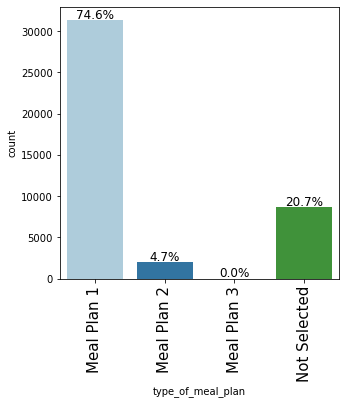

```python
labeled_barplot(logdata1, "type_of_meal_plan", perc=True)
```

Meal Plan 1 Accounts for the Majority of Meal Plan selections.

## Observations on Market Segments

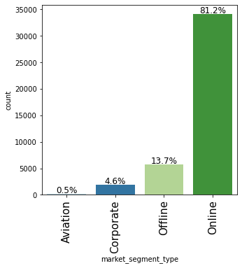

```python
labeled_barplot(logdata1, "market_segment_type", perc=True)
```

Online and Offline bookings account for most guest acquisition.

## Observations on Booking Statuses

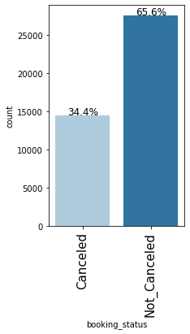

```python
labeled_barplot(logdata1, "booking_status", perc=True)
```

66% of bookings are not canceled.

## Observations on Room Types Reserved

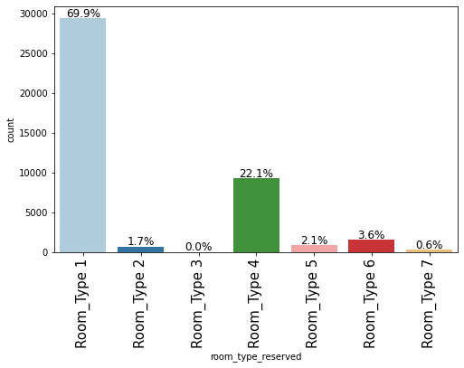

```python
labeled_barplot(logdata1, "room_type_reserved", perc=True)
```

## Observations on Months Reserved

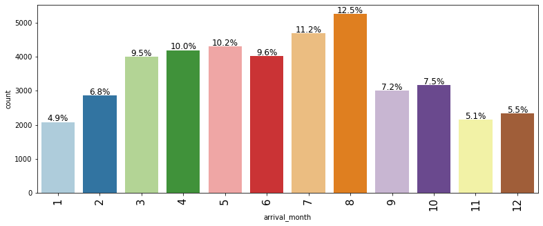

```python
labeled_barplot(logdata1, "arrival_month", perc=True)
```

The summer months are popular to be booked with August being the most popular booking month.

## Observations on booking Years

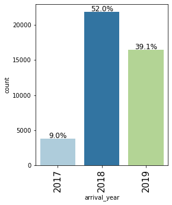

```python
labeled_barplot(logdata1, "arrival_year", perc=True)
```

2018 was the best year for bookings.

# Summary of Univariate Analysis

- August is the hotel's busiest month. Summer months are more busy than winter months.
- The most common market segment is online bookings.
- 34.4% of bookings are canceled.

# Bivariate Analysis

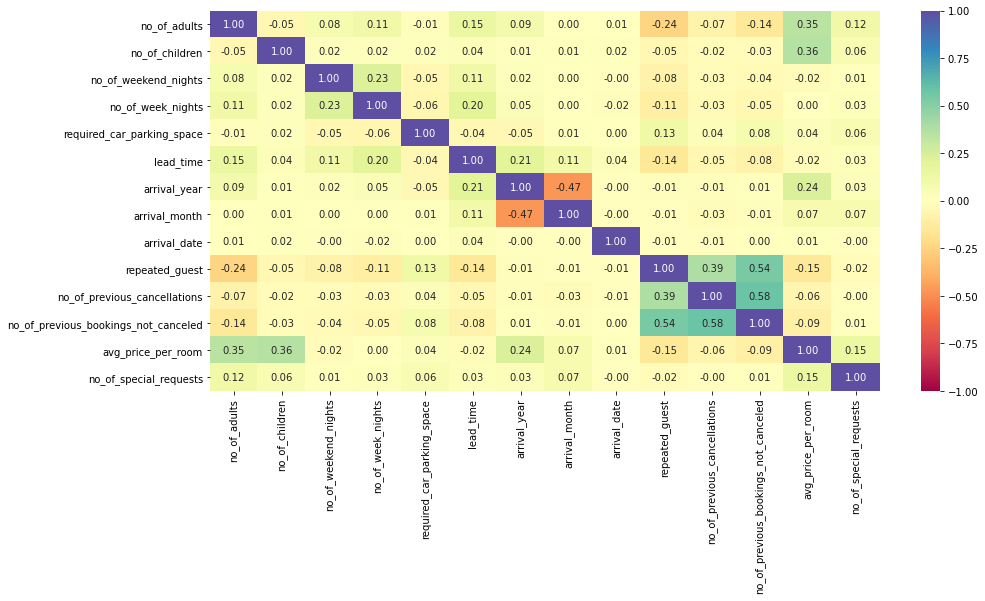

```python
plt.figure(figsize=(15, 7))
sns.heatmap(logdata1.corr(), annot=True, vmin=-1, vmax=1, fmt=".2f", cmap="Spectral")
plt.show()
```

- Repeat guests, number of previous cancellations, and number of previous bookings not canceled appear to be somewhat correlated.

```python
### Function to plot stacked bar charts for categorical columns
def stacked_plot(x):
    sns.set()
    ## crosstab
    tab1 = pd.crosstab(x, logdata1["booking_status"], margins=True).sort_values(
        by="Canceled", ascending=False
    )
    print(tab1)
    print("-" * 120)
    ## visualising the cross tab
    tab = pd.crosstab(x, logdata1["booking_data"], normalize="index").sort_values(
        by="Canceled", ascending=False
    )
    tab.plot(kind="bar", stacked=True, figsize=(17, 7))
    plt.legend(
        loc="lower left", frameon=False,
    )
    plt.legend(loc="upper left", bbox_to_anchor=(1, 1))
    plt.show()
```

```python
def stacked_barplot(data, predictor, target):
    """
    Print the category counts and plot a stacked bar chart

    data: dataframe
    predictor: independent variable
    target: target variable
    """
    count = logdata[predictor].nunique()
    sorter = logdata[target].value_counts().index[-1]
    tab1 = pd.crosstab(logdata1[predictor], logdata[target], margins=True).sort_values(
        by=sorter, ascending=False
    )
    print(tab1)
    print("-" * 120)
    tab = pd.crosstab(logdata1[predictor], logdata[target], normalize="index").sort_values(
        by=sorter, ascending=False
    )
    tab.plot(kind="bar", stacked=True, figsize=(count + 5, 5))
    plt.legend(
        loc="lower left", frameon=False,
    )
    plt.legend(loc="upper left", bbox_to_anchor=(1, 1))
    plt.show()
```

```
booking_status          Canceled  Not_Canceled    All
no_of_special_requests
All                        14487         27593  42080
0                           8752         10291  19043
1                           4346         11050  15396
2                           1389          4906   6295
3                              0          1194   1194
4                              0           136    136
5                              0            16     16
------------------------------------------------------------------------------------------------------------------------
```

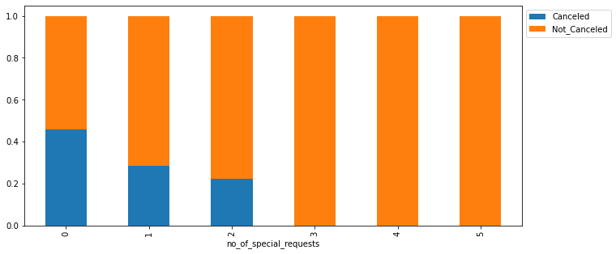

```python
stacked_barplot(logdata1, "no_of_special_requests", "booking_status")
```

```
booking_status       Canceled  Not_Canceled    All
market_segment_type
All                     14487         27593  42080
Online                  13483         20686  34169
Offline                   804          4973   5777
Corporate                 167          1772   1939
Aviation                   33           162    195
------------------------------------------------------------------------------------------------------------------------
```

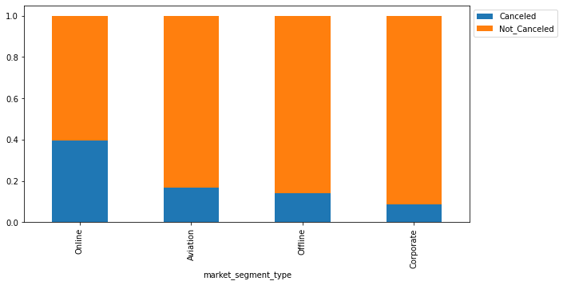

```python
stacked_barplot(logdata1, "market_segment_type", "booking_status")
```

- Corporate employees cancel the least amount of time.
- Online bookings are canceled ~40% of the time.

```
booking_status     Canceled  Not_Canceled    All
type_of_meal_plan
All                   14487         27593  42080
Meal Plan 1           10511         20881  31392
Not Selected           3118          5592   8710
Meal Plan 2             857          1120   1977
Meal Plan 3               1             0      1
------------------------------------------------------------------------------------------------------------------------
```

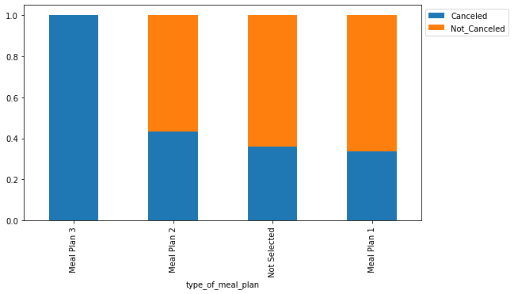

```python
stacked_barplot(logdata1, "type_of_meal_plan", "booking_status")
```

- Meal Plan 2 leads to canceled bookings over 40% of the time.
- Meal Plan 3 might need to be eliminated due to it rarely being selected.

```
booking_status      Canceled  Not_Canceled    All
room_type_reserved
All                    14487         27593  42080
Room_Type 1             9225         20192  29417
Room_Type 4             3683          5624   9307
Room_Type 6              826           692   1518
Room_Type 5              367           512    879
Room_Type 2              274           423    697
Room_Type 7              110           147    257
Room_Type 3                2             3      5
------------------------------------------------------------------------------------------------------------------------
```

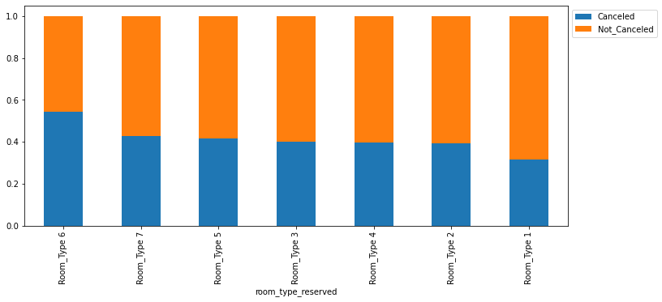

```python
stacked_barplot(logdata1, "room_type_reserved", "booking_status")
```

- Room type 6 leads to a greater than 50% cancellation rate.

```
booking_status  Canceled  Not_Canceled    All
no_of_adults
All                14487         27593  42080
2                  10998         19837  30835
3                   1813          2214   4027
1                   1589          5422   7011
0                     76           104    180
4                     11            16     27
------------------------------------------------------------------------------------------------------------------------
```

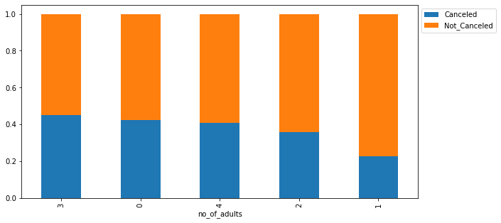

```python
stacked_barplot(logdata1, "no_of_adults", "booking_status")
```

- Bookings for one adult leads to the least likelyhood of cancellation.

```
booking_status  Canceled  Not_Canceled    All
no_of_children
All                14487         27593  42080
0                  12580         25268  37848
1                   1009          1527   2536
2                    883           773   1656
3                     14            23     37
9                      1             1      2
10                     0             1      1
------------------------------------------------------------------------------------------------------------------------
```

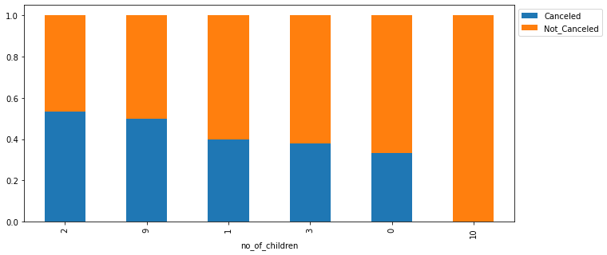

```python
stacked_barplot(logdata1, "no_of_children", "booking_status")
```

- Bookings with two children lead to the largest amount of cancellations.

```
booking_status  Canceled  Not_Canceled    All
arrival_month
All                14487         27593  42080
8                   2475          2788   5263
7                   2240          2455   4695
5                   1674          2629   4303
4                   1627          2569   4196
6                   1584          2441   4025
3                   1195          2805   4000
10                   918          2251   3169
9                    888          2121   3009
2                    796          2060   2856
11                   496          1654   2150
12                   340          1993   2333
1                    254          1827   2081
------------------------------------------------------------------------------------------------------------------------
```

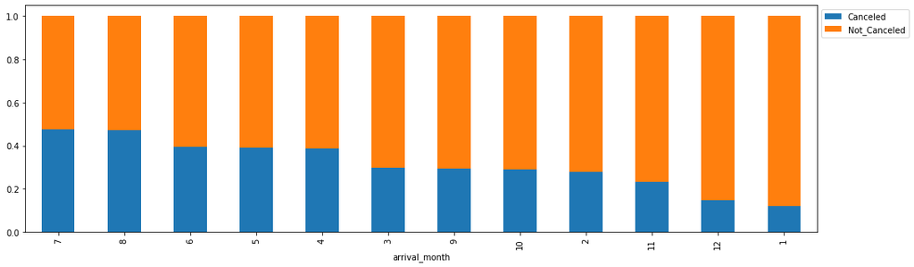

```python
stacked_barplot(logdata1, "arrival_month", "booking_status")
```

- July bookings are canceled roughly half the time.
- Summer Months lead to more cancellations than winter months.

```
booking_status  Canceled  Not_Canceled    All
repeated_guest
All                14487         27593  42080
0                  14477         26492  40969
1                     10          1101   1111
------------------------------------------------------------------------------------------------------------------------
```

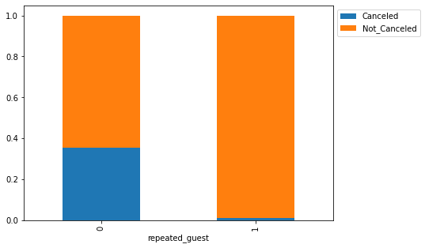

```python
stacked_barplot(logdata1, "repeated_guest", "booking_status")
```

- Repeat Guests rarely cancel.

```
booking_status        Canceled  Not_Canceled    All
no_of_weekend_nights
All                      14487         27593  42080
0                         5630         11826  17456
2                         4417          7544  11961
1                         4130          8034  12164
4                          148            67    215
3                          117           103    220
5                           21             9     30
6                           21            10     31
8                            2             0      2
7                            1             0      1
------------------------------------------------------------------------------------------------------------------------
```

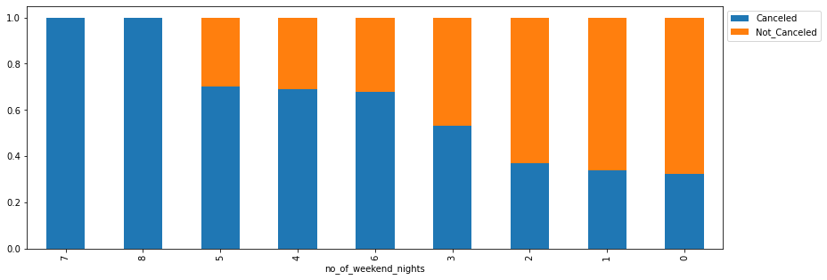

```python
stacked_barplot(logdata1, "no_of_weekend_nights", "booking_status")
```

```
booking_status     Canceled  Not_Canceled    All
no_of_week_nights
All                   14487         27593  42080
2                      3979          7684  11663
3                      3483          6162   9645
1                      3038          7578  10616
4                      1704          2430   4134
5                      1104          1398   2502
0                       691          2025   2716
6                       161           140    301
7                        90            72    162
10                       79            14     93
8                        74            47    121
9                        29            19     48
11                       17             3     20
12                       11             5     16
15                        8             6     14
13                        7             2      9
14                        5             5     10
16                        5             2      7
17                        2             1      3
------------------------------------------------------------------------------------------------------------------------
```

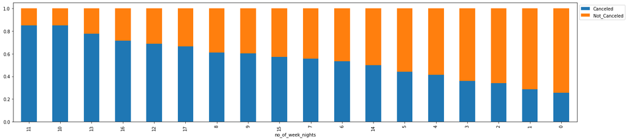

```python
stacked_barplot(logdata1, "no_of_week_nights", "booking_status")
```

- Visits for weekend nights and week nights greater than 5 days appear to lead to a greater than 50% cancellation rate.

```
booking_status                Canceled  Not_Canceled    All
no_of_previous_cancellations
All                              14487         27593  42080
0                                14477         27223  41700
1                                    8           220    228
3                                    1            39     40
13                                   1             0      1
2                                    0            49     49
4                                    0            10     10
5                                    0            11     11
6                                    0            16     16
11                                   0            25     25
------------------------------------------------------------------------------------------------------------------------
```

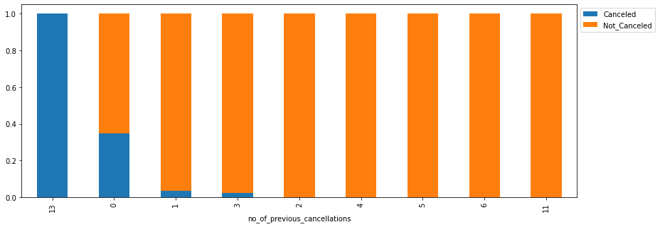

```python
stacked_barplot(logdata1, "no_of_previous_cancellations", "booking_status")
```

- Number of previous cancellations appear to be statistically irrelevant as this statistic was collected for only 10 cancellations.

```
booking_status                        Canceled  Not_Canceled    All
no_of_previous_bookings_not_canceled
All                                      14487         27593  42080
0                                        14482         26537  41019
12                                           1            19     20
4                                            1            78     79
6                                            1            45     46
1                                            1           297    298
10                                           1            24     25
49                                           0             1      1
55                                           0             1      1
54                                           0             1      1
53                                           0             1      1
52                                           0             1      1
51                                           0             1      1
```

[output cut: 62 more lines]

[figure not shown]

```python
stacked_barplot(logdata1, "no_of_previous_bookings_not_canceled", "booking_status")
```

- Number of previous cancellations appear to be statistically irrelevant as this statistic was collected for only 5 cancellations.